# ambrosio_homework_2

## LUCA AMBROSIO

### HOMEWORK 2

This homework is based on the wine quality classification research paper and dataset shared on the course page.

## What to do

The homework consists in building a classification model which is able to predict the quality of the wine (binary classification) based on its physicochemical values.

## Approach

The idea is to apply different approaches and evaluate them, in terms of Accuracy, Precision-per class and Recall-per class. You can apply the hold-out validation methodology, selecting randomly 20% of a dataset for testing. Per each approach, plot also the Confusion Matrix and make some reasoning over it

## 1.

Apply a Logistic Regression algorithm on the 2 datasets, separately. Create a new target class binning the quality in 2 sets:for example, if quality>=5 => target_quality=high, if quality<5 => target_quality=low. Build a model for the red wine dataset, and a model for the white wine dataset.

Import useful libraries for the performance of the exercise

```python
import pandas as pd
import numpy as np
import seaborn as sns
import matplotlib
from matplotlib import pyplot as plt
from sklearn.model_selection import train_test_split
from sklearn.linear_model import LogisticRegression, LinearRegression
from sklearn.metrics import accuracy_score, confusion_matrix, classification_report
```

we use the sep parameter to specify the separator used in our csv file

```python
data1 = pd.read_csv("winequality-white.csv", error_bad_lines=False, sep = ';')
```

```python
data2 = pd.read_csv("winequality-red.csv", error_bad_lines=False,  sep = ';')
```

I study the values contained within the dataset and how the following dataset is structured

```python
data1.shape
```

```
(4898, 12)
```

```python
data2.shape
```

```
(1599, 12)
```

```python
data1.head(20)
```

|  | fixed acidity | volatile acidity | citric acid | residual sugar | chlorides | free sulfur dioxide | total sulfur dioxide | density | pH | sulphates | alcohol | quality |
| --- | --- | --- | --- | --- | --- | --- | --- | --- | --- | --- | --- | --- |
| 0 | 7.0 | 0.27 | 0.36 | 20.70 | 0.045 | 45.0 | 170.0 | 1.0010 | 3.00 | 0.45 | 8.8 | 6 |
| 1 | 6.3 | 0.30 | 0.34 | 1.60 | 0.049 | 14.0 | 132.0 | 0.9940 | 3.30 | 0.49 | 9.5 | 6 |
| 2 | 8.1 | 0.28 | 0.40 | 6.90 | 0.050 | 30.0 | 97.0 | 0.9951 | 3.26 | 0.44 | 10.1 | 6 |
| 3 | 7.2 | 0.23 | 0.32 | 8.50 | 0.058 | 47.0 | 186.0 | 0.9956 | 3.19 | 0.40 | 9.9 | 6 |
| 4 | 7.2 | 0.23 | 0.32 | 8.50 | 0.058 | 47.0 | 186.0 | 0.9956 | 3.19 | 0.40 | 9.9 | 6 |
| 5 | 8.1 | 0.28 | 0.40 | 6.90 | 0.050 | 30.0 | 97.0 | 0.9951 | 3.26 | 0.44 | 10.1 | 6 |
| 6 | 6.2 | 0.32 | 0.16 | 7.00 | 0.045 | 30.0 | 136.0 | 0.9949 | 3.18 | 0.47 | 9.6 | 6 |
| 7 | 7.0 | 0.27 | 0.36 | 20.70 | 0.045 | 45.0 | 170.0 | 1.0010 | 3.00 | 0.45 | 8.8 | 6 |
| 8 | 6.3 | 0.30 | 0.34 | 1.60 | 0.049 | 14.0 | 132.0 | 0.9940 | 3.30 | 0.49 | 9.5 | 6 |
| 9 | 8.1 | 0.22 | 0.43 | 1.50 | 0.044 | 28.0 | 129.0 | 0.9938 | 3.22 | 0.45 | 11.0 | 6 |
| 10 | 8.1 | 0.27 | 0.41 | 1.45 | 0.033 | 11.0 | 63.0 | 0.9908 | 2.99 | 0.56 | 12.0 | 5 |
| 11 | 8.6 | 0.23 | 0.40 | 4.20 | 0.035 | 17.0 | 109.0 | 0.9947 | 3.14 | 0.53 | 9.7 | 5 |
| 12 | 7.9 | 0.18 | 0.37 | 1.20 | 0.040 | 16.0 | 75.0 | 0.9920 | 3.18 | 0.63 | 10.8 | 5 |
| 13 | 6.6 | 0.16 | 0.40 | 1.50 | 0.044 | 48.0 | 143.0 | 0.9912 | 3.54 | 0.52 | 12.4 | 7 |
| 14 | 8.3 | 0.42 | 0.62 | 19.25 | 0.040 | 41.0 | 172.0 | 1.0002 | 2.98 | 0.67 | 9.7 | 5 |
| 15 | 6.6 | 0.17 | 0.38 | 1.50 | 0.032 | 28.0 | 112.0 | 0.9914 | 3.25 | 0.55 | 11.4 | 7 |
| 16 | 6.3 | 0.48 | 0.04 | 1.10 | 0.046 | 30.0 | 99.0 | 0.9928 | 3.24 | 0.36 | 9.6 | 6 |
| 17 | 6.2 | 0.66 | 0.48 | 1.20 | 0.029 | 29.0 | 75.0 | 0.9892 | 3.33 | 0.39 | 12.8 | 8 |
| 18 | 7.4 | 0.34 | 0.42 | 1.10 | 0.033 | 17.0 | 171.0 | 0.9917 | 3.12 | 0.53 | 11.3 | 6 |
| 19 | 6.5 | 0.31 | 0.14 | 7.50 | 0.044 | 34.0 | 133.0 | 0.9955 | 3.22 | 0.50 | 9.5 | 5 |

```python
data2.head(20)
```

|  | fixed acidity | volatile acidity | citric acid | residual sugar | chlorides | free sulfur dioxide | total sulfur dioxide | density | pH | sulphates | alcohol | quality |
| --- | --- | --- | --- | --- | --- | --- | --- | --- | --- | --- | --- | --- |
| 0 | 7.4 | 0.700 | 0.00 | 1.9 | 0.076 | 11.0 | 34.0 | 0.9978 | 3.51 | 0.56 | 9.4 | 5 |
| 1 | 7.8 | 0.880 | 0.00 | 2.6 | 0.098 | 25.0 | 67.0 | 0.9968 | 3.20 | 0.68 | 9.8 | 5 |
| 2 | 7.8 | 0.760 | 0.04 | 2.3 | 0.092 | 15.0 | 54.0 | 0.9970 | 3.26 | 0.65 | 9.8 | 5 |
| 3 | 11.2 | 0.280 | 0.56 | 1.9 | 0.075 | 17.0 | 60.0 | 0.9980 | 3.16 | 0.58 | 9.8 | 6 |
| 4 | 7.4 | 0.700 | 0.00 | 1.9 | 0.076 | 11.0 | 34.0 | 0.9978 | 3.51 | 0.56 | 9.4 | 5 |
| 5 | 7.4 | 0.660 | 0.00 | 1.8 | 0.075 | 13.0 | 40.0 | 0.9978 | 3.51 | 0.56 | 9.4 | 5 |
| 6 | 7.9 | 0.600 | 0.06 | 1.6 | 0.069 | 15.0 | 59.0 | 0.9964 | 3.30 | 0.46 | 9.4 | 5 |
| 7 | 7.3 | 0.650 | 0.00 | 1.2 | 0.065 | 15.0 | 21.0 | 0.9946 | 3.39 | 0.47 | 10.0 | 7 |
| 8 | 7.8 | 0.580 | 0.02 | 2.0 | 0.073 | 9.0 | 18.0 | 0.9968 | 3.36 | 0.57 | 9.5 | 7 |
| 9 | 7.5 | 0.500 | 0.36 | 6.1 | 0.071 | 17.0 | 102.0 | 0.9978 | 3.35 | 0.80 | 10.5 | 5 |
| 10 | 6.7 | 0.580 | 0.08 | 1.8 | 0.097 | 15.0 | 65.0 | 0.9959 | 3.28 | 0.54 | 9.2 | 5 |
| 11 | 7.5 | 0.500 | 0.36 | 6.1 | 0.071 | 17.0 | 102.0 | 0.9978 | 3.35 | 0.80 | 10.5 | 5 |
| 12 | 5.6 | 0.615 | 0.00 | 1.6 | 0.089 | 16.0 | 59.0 | 0.9943 | 3.58 | 0.52 | 9.9 | 5 |
| 13 | 7.8 | 0.610 | 0.29 | 1.6 | 0.114 | 9.0 | 29.0 | 0.9974 | 3.26 | 1.56 | 9.1 | 5 |
| 14 | 8.9 | 0.620 | 0.18 | 3.8 | 0.176 | 52.0 | 145.0 | 0.9986 | 3.16 | 0.88 | 9.2 | 5 |
| 15 | 8.9 | 0.620 | 0.19 | 3.9 | 0.170 | 51.0 | 148.0 | 0.9986 | 3.17 | 0.93 | 9.2 | 5 |
| 16 | 8.5 | 0.280 | 0.56 | 1.8 | 0.092 | 35.0 | 103.0 | 0.9969 | 3.30 | 0.75 | 10.5 | 7 |
| 17 | 8.1 | 0.560 | 0.28 | 1.7 | 0.368 | 16.0 | 56.0 | 0.9968 | 3.11 | 1.28 | 9.3 | 5 |
| 18 | 7.4 | 0.590 | 0.08 | 4.4 | 0.086 | 6.0 | 29.0 | 0.9974 | 3.38 | 0.50 | 9.0 | 4 |
| 19 | 7.9 | 0.320 | 0.51 | 1.8 | 0.341 | 17.0 | 56.0 | 0.9969 | 3.04 | 1.08 | 9.2 | 6 |

```python
data1.describe()
```

|  | fixed acidity | volatile acidity | citric acid | residual sugar | chlorides | free sulfur dioxide | total sulfur dioxide | density | pH | sulphates | alcohol | quality |
| --- | --- | --- | --- | --- | --- | --- | --- | --- | --- | --- | --- | --- |
| count | 4898.000000 | 4898.000000 | 4898.000000 | 4898.000000 | 4898.000000 | 4898.000000 | 4898.000000 | 4898.000000 | 4898.000000 | 4898.000000 | 4898.000000 | 4898.000000 |
| mean | 6.854788 | 0.278241 | 0.334192 | 6.391415 | 0.045772 | 35.308085 | 138.360657 | 0.994027 | 3.188267 | 0.489847 | 10.514267 | 5.877909 |
| std | 0.843868 | 0.100795 | 0.121020 | 5.072058 | 0.021848 | 17.007137 | 42.498065 | 0.002991 | 0.151001 | 0.114126 | 1.230621 | 0.885639 |
| min | 3.800000 | 0.080000 | 0.000000 | 0.600000 | 0.009000 | 2.000000 | 9.000000 | 0.987110 | 2.720000 | 0.220000 | 8.000000 | 3.000000 |
| 25% | 6.300000 | 0.210000 | 0.270000 | 1.700000 | 0.036000 | 23.000000 | 108.000000 | 0.991723 | 3.090000 | 0.410000 | 9.500000 | 5.000000 |
| 50% | 6.800000 | 0.260000 | 0.320000 | 5.200000 | 0.043000 | 34.000000 | 134.000000 | 0.993740 | 3.180000 | 0.470000 | 10.400000 | 6.000000 |
| 75% | 7.300000 | 0.320000 | 0.390000 | 9.900000 | 0.050000 | 46.000000 | 167.000000 | 0.996100 | 3.280000 | 0.550000 | 11.400000 | 6.000000 |
| max | 14.200000 | 1.100000 | 1.660000 | 65.800000 | 0.346000 | 289.000000 | 440.000000 | 1.038980 | 3.820000 | 1.080000 | 14.200000 | 9.000000 |

```python
data2.describe()
```

|  | fixed acidity | volatile acidity | citric acid | residual sugar | chlorides | free sulfur dioxide | total sulfur dioxide | density | pH | sulphates | alcohol | quality |
| --- | --- | --- | --- | --- | --- | --- | --- | --- | --- | --- | --- | --- |
| count | 1599.000000 | 1599.000000 | 1599.000000 | 1599.000000 | 1599.000000 | 1599.000000 | 1599.000000 | 1599.000000 | 1599.000000 | 1599.000000 | 1599.000000 | 1599.000000 |
| mean | 8.319637 | 0.527821 | 0.270976 | 2.538806 | 0.087467 | 15.874922 | 46.467792 | 0.996747 | 3.311113 | 0.658149 | 10.422983 | 5.636023 |
| std | 1.741096 | 0.179060 | 0.194801 | 1.409928 | 0.047065 | 10.460157 | 32.895324 | 0.001887 | 0.154386 | 0.169507 | 1.065668 | 0.807569 |
| min | 4.600000 | 0.120000 | 0.000000 | 0.900000 | 0.012000 | 1.000000 | 6.000000 | 0.990070 | 2.740000 | 0.330000 | 8.400000 | 3.000000 |
| 25% | 7.100000 | 0.390000 | 0.090000 | 1.900000 | 0.070000 | 7.000000 | 22.000000 | 0.995600 | 3.210000 | 0.550000 | 9.500000 | 5.000000 |
| 50% | 7.900000 | 0.520000 | 0.260000 | 2.200000 | 0.079000 | 14.000000 | 38.000000 | 0.996750 | 3.310000 | 0.620000 | 10.200000 | 6.000000 |
| 75% | 9.200000 | 0.640000 | 0.420000 | 2.600000 | 0.090000 | 21.000000 | 62.000000 | 0.997835 | 3.400000 | 0.730000 | 11.100000 | 6.000000 |
| max | 15.900000 | 1.580000 | 1.000000 | 15.500000 | 0.611000 | 72.000000 | 289.000000 | 1.003690 | 4.010000 | 2.000000 | 14.900000 | 8.000000 |

```python
data1.describe(include='all') #includes also the cathegorical values
```

|  | fixed acidity | volatile acidity | citric acid | residual sugar | chlorides | free sulfur dioxide | total sulfur dioxide | density | pH | sulphates | alcohol | quality |
| --- | --- | --- | --- | --- | --- | --- | --- | --- | --- | --- | --- | --- |
| count | 4898.000000 | 4898.000000 | 4898.000000 | 4898.000000 | 4898.000000 | 4898.000000 | 4898.000000 | 4898.000000 | 4898.000000 | 4898.000000 | 4898.000000 | 4898.000000 |
| mean | 6.854788 | 0.278241 | 0.334192 | 6.391415 | 0.045772 | 35.308085 | 138.360657 | 0.994027 | 3.188267 | 0.489847 | 10.514267 | 5.877909 |
| std | 0.843868 | 0.100795 | 0.121020 | 5.072058 | 0.021848 | 17.007137 | 42.498065 | 0.002991 | 0.151001 | 0.114126 | 1.230621 | 0.885639 |
| min | 3.800000 | 0.080000 | 0.000000 | 0.600000 | 0.009000 | 2.000000 | 9.000000 | 0.987110 | 2.720000 | 0.220000 | 8.000000 | 3.000000 |
| 25% | 6.300000 | 0.210000 | 0.270000 | 1.700000 | 0.036000 | 23.000000 | 108.000000 | 0.991723 | 3.090000 | 0.410000 | 9.500000 | 5.000000 |
| 50% | 6.800000 | 0.260000 | 0.320000 | 5.200000 | 0.043000 | 34.000000 | 134.000000 | 0.993740 | 3.180000 | 0.470000 | 10.400000 | 6.000000 |
| 75% | 7.300000 | 0.320000 | 0.390000 | 9.900000 | 0.050000 | 46.000000 | 167.000000 | 0.996100 | 3.280000 | 0.550000 | 11.400000 | 6.000000 |
| max | 14.200000 | 1.100000 | 1.660000 | 65.800000 | 0.346000 | 289.000000 | 440.000000 | 1.038980 | 3.820000 | 1.080000 | 14.200000 | 9.000000 |

```python
data2.describe(include='all') #includes also the cathegorical values
```

|  | fixed acidity | volatile acidity | citric acid | residual sugar | chlorides | free sulfur dioxide | total sulfur dioxide | density | pH | sulphates | alcohol | quality |
| --- | --- | --- | --- | --- | --- | --- | --- | --- | --- | --- | --- | --- |
| count | 1599.000000 | 1599.000000 | 1599.000000 | 1599.000000 | 1599.000000 | 1599.000000 | 1599.000000 | 1599.000000 | 1599.000000 | 1599.000000 | 1599.000000 | 1599.000000 |
| mean | 8.319637 | 0.527821 | 0.270976 | 2.538806 | 0.087467 | 15.874922 | 46.467792 | 0.996747 | 3.311113 | 0.658149 | 10.422983 | 5.636023 |
| std | 1.741096 | 0.179060 | 0.194801 | 1.409928 | 0.047065 | 10.460157 | 32.895324 | 0.001887 | 0.154386 | 0.169507 | 1.065668 | 0.807569 |
| min | 4.600000 | 0.120000 | 0.000000 | 0.900000 | 0.012000 | 1.000000 | 6.000000 | 0.990070 | 2.740000 | 0.330000 | 8.400000 | 3.000000 |
| 25% | 7.100000 | 0.390000 | 0.090000 | 1.900000 | 0.070000 | 7.000000 | 22.000000 | 0.995600 | 3.210000 | 0.550000 | 9.500000 | 5.000000 |
| 50% | 7.900000 | 0.520000 | 0.260000 | 2.200000 | 0.079000 | 14.000000 | 38.000000 | 0.996750 | 3.310000 | 0.620000 | 10.200000 | 6.000000 |
| 75% | 9.200000 | 0.640000 | 0.420000 | 2.600000 | 0.090000 | 21.000000 | 62.000000 | 0.997835 | 3.400000 | 0.730000 | 11.100000 | 6.000000 |
| max | 15.900000 | 1.580000 | 1.000000 | 15.500000 | 0.611000 | 72.000000 | 289.000000 | 1.003690 | 4.010000 | 2.000000 | 14.900000 | 8.000000 |

```python
data1.dtypes
```

```
fixed acidity           float64
volatile acidity        float64
citric acid             float64
residual sugar          float64
chlorides               float64
free sulfur dioxide     float64
total sulfur dioxide    float64
density                 float64
pH                      float64
sulphates               float64
alcohol                 float64
quality                   int64
dtype: object
```

```python
data1['target_quality'] = "high"
data2['target_quality'] = "high"
```

```python
data1["target_quality"][data1["quality"]<5]="low"
data2["target_quality"][data2["quality"]<5]="low"
```

```
accuracy = 0.9693877551020408
              precision    recall  f1-score   support

        high       0.97      1.00      0.98       950
         low       0.00      0.00      0.00        30

   micro avg       0.97      0.97      0.97       980
   macro avg       0.48      0.50      0.49       980
weighted avg       0.94      0.97      0.95       980
```

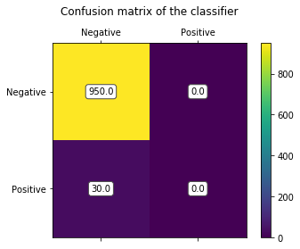

```python
#white wine

import pandas as pd
import numpy as np
from sklearn import linear_model
from sklearn.model_selection import train_test_split

x = data1[["fixed acidity","volatile acidity","citric acid","residual sugar","chlorides","free sulfur dioxide","total sulfur dioxide","density","pH","sulphates","alcohol"]]
y = data1["target_quality"]


[xTrain, xTest] = train_test_split(x, test_size=0.2, random_state=42) # la dimensione del test set è il 30% del dataset
[yTrain, yTest] = train_test_split(y, test_size=0.2, random_state=42) # la dimensione del test set è il 30% del dataset


clf = LogisticRegression(solver='lbfgs', max_iter=1000)
clf.fit(xTrain[["fixed acidity","volatile acidity","citric acid","residual sugar","chlorides","free sulfur dioxide","total sulfur dioxide","density","pH","sulphates","alcohol"]], yTrain)
y_hat = clf.predict(xTest[["fixed acidity","volatile acidity","citric acid","residual sugar","chlorides","free sulfur dioxide","total sulfur dioxide","density","pH","sulphates","alcohol"]])

# Calculate the accuracy
accuracy = accuracy_score(yTest, y_hat)
print("accuracy = {}".format(accuracy))


# Print precision, recall, f1-score
print(classification_report(yTest, y_hat))

# Compute and show the confusion matrix
confusion_matrixr = confusion_matrix(yTest, y_hat)

labels = ['Negative', 'Positive']

fig = plt.figure()
ax = fig.add_subplot(111)

#plot the heatmap
cax = ax.matshow(confusion_matrixr)

#write number on each square
for (i, j), z in np.ndenumerate(confusion_matrixr):
    ax.text(j, i, '{:0.1f}'.format(z), ha='center', va='center',
            bbox=dict(boxstyle='round', facecolor='white', edgecolor='0.3'))

plt.title('Confusion matrix of the classifier\n')
fig.colorbar(cax)
ax.set_xticklabels([''] + labels)
ax.set_yticklabels([''] + labels)

plt.show()
```

```
accuracy = 0.965625
              precision    recall  f1-score   support

        high       0.97      1.00      0.98       309
         low       0.00      0.00      0.00        11

   micro avg       0.97      0.97      0.97       320
   macro avg       0.48      0.50      0.49       320
weighted avg       0.93      0.97      0.95       320
```

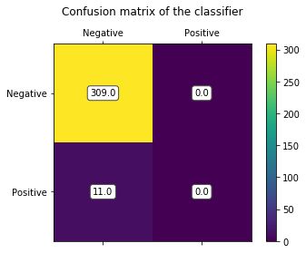

```python
#red wine

import pandas as pd
import numpy as np
from sklearn import linear_model
from sklearn.model_selection import train_test_split

x = data2[["fixed acidity","volatile acidity","citric acid","residual sugar","chlorides","free sulfur dioxide","total sulfur dioxide","density","pH","sulphates","alcohol"]]
y = data2["target_quality"]


[xTrain, xTest] = train_test_split(x, test_size=0.2, random_state=42) # la dimensione del test set è il 30% del dataset
[yTrain, yTest] = train_test_split(y, test_size=0.2, random_state=42) # la dimensione del test set è il 30% del dataset


clf = LogisticRegression(solver='lbfgs', max_iter=1000)
clf.fit(xTrain[["fixed acidity","volatile acidity","citric acid","residual sugar","chlorides","free sulfur dioxide","total sulfur dioxide","density","pH","sulphates","alcohol"]], yTrain)
y_hat = clf.predict(xTest[["fixed acidity","volatile acidity","citric acid","residual sugar","chlorides","free sulfur dioxide","total sulfur dioxide","density","pH","sulphates","alcohol"]])

# Calculate the accuracy
accuracy = accuracy_score(yTest, y_hat)
print("accuracy = {}".format(accuracy))


# Print precision, recall, f1-score
print(classification_report(yTest, y_hat))

# Compute and show the confusion matrix
confusion_matrixw = confusion_matrix(yTest, y_hat)

labels = ['Negative', 'Positive']

fig = plt.figure()
ax = fig.add_subplot(111)

#plot the heatmap
cax = ax.matshow(confusion_matrixw)

#write number on each square
for (i, j), z in np.ndenumerate(confusion_matrixw):
    ax.text(j, i, '{:0.1f}'.format(z), ha='center', va='center',
            bbox=dict(boxstyle='round', facecolor='white', edgecolor='0.3'))

plt.title('Confusion matrix of the classifier\n')
fig.colorbar(cax)
ax.set_xticklabels([''] + labels)
ax.set_yticklabels([''] + labels)

plt.show()
```

## 2.

Apply Logistic Regression algorithm on the complete dataset, considering together red and white wines, and adding a feature column named "wine_type", whose elements can assume the values {'red', 'white'}.

```
accuracy = 0.9646153846153847
              precision    recall  f1-score   support

        high       0.96      1.00      0.98      1252
         low       1.00      0.04      0.08        48

   micro avg       0.96      0.96      0.96      1300
   macro avg       0.98      0.52      0.53      1300
weighted avg       0.97      0.96      0.95      1300
```

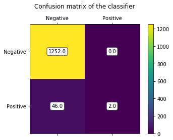

```python
data1["wine_type"]= 1   #white
data2["wine_type"]= 0   #red
merged = pd.concat([data1,data2], ignore_index=True, sort=False)
#print(merged.head(50))
#train and test division
x = merged[["fixed acidity","volatile acidity","citric acid","residual sugar","chlorides","free sulfur dioxide","total sulfur dioxide","density","pH","sulphates","alcohol","wine_type"]]
y = merged["target_quality"]

[xTrain, xTest] = train_test_split(x, test_size=0.2, random_state=42) # la dimensione del test set è il 30% del dataset
[yTrain, yTest] = train_test_split(y, test_size=0.2, random_state=42) # la dimensione del test set è il 30% del dataset


clf = LogisticRegression(solver='lbfgs', max_iter=1000)
clf.fit(xTrain[["fixed acidity","volatile acidity","citric acid","residual sugar","chlorides","free sulfur dioxide","total sulfur dioxide","density","pH","sulphates","alcohol","wine_type"]], yTrain)
y_hat = clf.predict(xTest[["fixed acidity","volatile acidity","citric acid","residual sugar","chlorides","free sulfur dioxide","total sulfur dioxide","density","pH","sulphates","alcohol","wine_type"]])

# Calculate the accuracy
accuracy = accuracy_score(yTest, y_hat)
print("accuracy = {}".format(accuracy))


# Print precision, recall, f1-score
print(classification_report(yTest, y_hat))

# Compute and show the confusion matrix
confusion_matrixm = confusion_matrix(yTest, y_hat)

labels = ['Negative', 'Positive']

fig = plt.figure()
ax = fig.add_subplot(111)

#plot the heatmap
cax = ax.matshow(confusion_matrixm)

#write number on each square
for (i, j), z in np.ndenumerate(confusion_matrixm):
    ax.text(j, i, '{:0.1f}'.format(z), ha='center', va='center',
            bbox=dict(boxstyle='round', facecolor='white', edgecolor='0.3'))

plt.title('Confusion matrix of the classifier\n')
fig.colorbar(cax)
ax.set_xticklabels([''] + labels)
ax.set_yticklabels([''] + labels)

plt.show()
```

## 3.

Apply a Linear Regression algorithm, considering the quality measure learned as a continuous value. When evaluating the prediction, make an approximation on the quality value predicted by the linear regression model to retrieve a target_quality (with the same procedure asin point 1). Evaluate the target_quality prediction on the binned real_quality.

```python
# find correlations to target
corr_matrix = merged.corr().abs()
print(corr_matrix['quality'].sort_values(ascending=False))
```

```
quality                 1.000000
alcohol                 0.444319
density                 0.305858
volatile acidity        0.265699
chlorides               0.200666
wine_type               0.119323
citric acid             0.085532
fixed acidity           0.076743
free sulfur dioxide     0.055463
total sulfur dioxide    0.041385
sulphates               0.038485
residual sugar          0.036980
pH                      0.019506
Name: quality, dtype: float64
```

```python
x = merged[["fixed acidity","volatile acidity","citric acid","residual sugar","chlorides","free sulfur dioxide","total sulfur dioxide","density","pH","sulphates","alcohol","wine_type"]]
y = merged["quality"]

[xTrain, xTest] = train_test_split(x, test_size=0.2, random_state=42) # la dimensione del test set è il 30% del dataset
[yTrain, yTest] = train_test_split(y, test_size=0.2, random_state=42) # la dimensione del test set è il 30% del dataset


clf = LinearRegression()
clf.fit(xTrain[["fixed acidity","volatile acidity","citric acid","residual sugar","chlorides","free sulfur dioxide","total sulfur dioxide","density","pH","sulphates","alcohol","wine_type"]], yTrain)
y_hat = clf.predict(xTest[["fixed acidity","volatile acidity","citric acid","residual sugar","chlorides","free sulfur dioxide","total sulfur dioxide","density","pH","sulphates","alcohol","wine_type"]])


print("intercept = {}".format(clf.intercept_))
print("coeff = {}".format(clf.coef_))

# Performance evaluation
yTestMean = yTest.mean()
n = len(yTest)

SST = np.sum((yTest - yTestMean) ** 2) / n
print("SST = {}".format(SST))

SSE =  np.sum((yTest - y_hat) ** 2) / n
print("SEE = {}".format(SSE))

R_square = 1 - (SSE / SST)
print("R-square = {}".format(R_square))

print("The selected attributes explain {}% of the variation in quality".format(R_square))


# Convert to target_quality and calculate the accurancy
correct_predictions_count = 0
for index, value in enumerate(yTest):
    if y_hat[index]>=5 and value>=5 or y_hat[index]<5 and value<5:
        correct_predictions_count += 1

print("The selected attributes explain {}% of the variation in target_quality"
      .format((correct_predictions_count/len(y_hat))*100))
```

```
intercept = 97.32508236351951
coeff = [ 8.00801947e-02 -1.47605476e+00 -4.56634941e-02  6.09871341e-02
 -6.52423010e-01  5.28226063e-03 -1.63721815e-03 -9.63038156e+01
  4.46988391e-01  7.33912294e-01  2.27337526e-01 -3.42970486e-01]
SST = 0.7147994082840237
SEE = 0.47203733312735
R-square = 0.33962265824961735
The selected attributes explain 0.33962265824961735% of the variation in quality
The selected attributes explain 94.6923076923077% of the variation in target_quality
```

Linear regression works worse than logistic regression but it also allows us to understand the difference between a low quality wine and a high quality wine.